# punto 6

En la siguiente gráfica la varible dependiente es la duracion (eje y), explicada a traves de la densidad (eje x) y la temperatura (el color). De la grafica que puede observar que a mayor densidad se obtiene menor duración, que a menor temperatura mayor duración, y además una combinación de baja temperatura y baja densidad produce los mejores resultados.

A simple vista no parecen haber puntos influyentes.

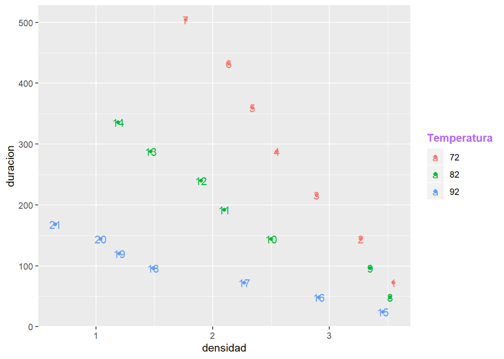

Para evaluar si la interaccion es significativa se revisa CM(densidad*temperatura)/CM(error), esto se puede revisar mediante el procedimiento lm de R. a un nivel de significancia alpha del 5% la interaccion es significativa.

```
##                      Df Sum Sq Mean Sq F value   Pr(>F)
## densidad              1  53695   53695   82.59 6.17e-08 ***
## temperatura           1 228774  228774  351.89 8.51e-13 ***
## densidad:temperatura  1  61294   61294   94.28 2.38e-08 ***
## Residuals            17  11052     650
## ---
## Signif. codes:  0 '***' 0.001 '**' 0.01 '*' 0.05 '.' 0.1 ' ' 1
```

A continuacion se presenta una grafica de los residuales versus los valores ajustados que deben ser independientes ya que el modelo tiene intercepto

# residuales vs estimados

De las siguientes gráficas se hace el siguiente análisis descriptivo:

Parece que las varianzas no son constantes en los niveles de la temperatura

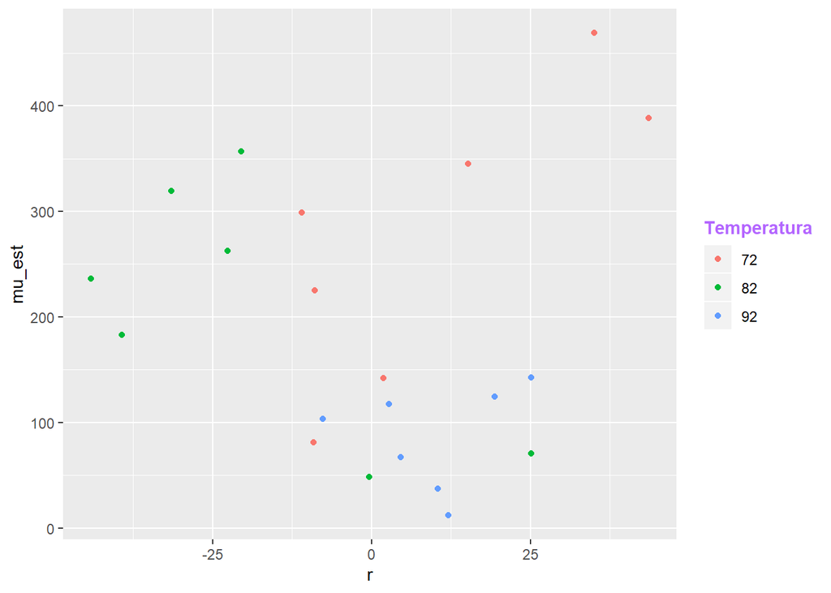

```r
####################################################################
# residuales vs estimados

r = lm1$residuals
mu_est = lm1$fitted.values


resvsest =data.frame(r,mu_est)

gg2 = ggplot(resvsest,aes(x = r,y = mu_est,color = as.factor(temperatura)))+geom_point()

gg2 = gg2 +tema + labs(color = "Temperatura")

gg2
```

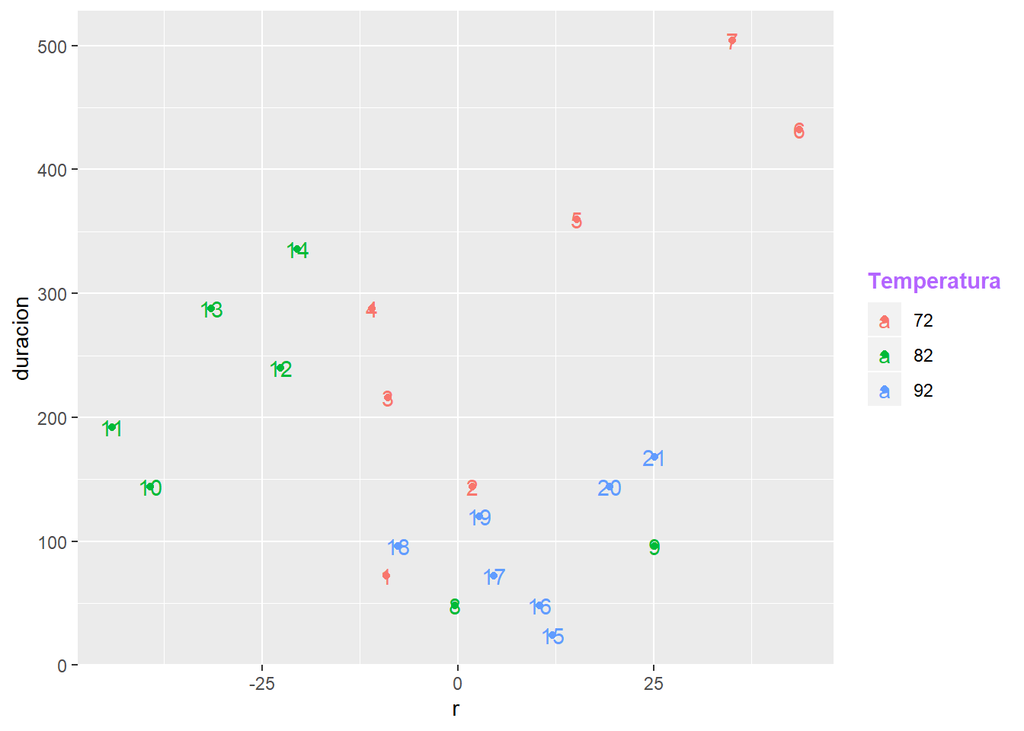

```r
####################################################################
# residuales vs obs

r = lm1$residuals

resvsest =data.frame(r,mu_est)

gg2 = ggplot(resvsest,aes(x = r,y = duracion ,color = as.factor(temperatura)))+geom_point()

gg2 = gg2 +tema + labs(color = "Temperatura")
gg2 +geom_text(aes(label = rownames(resvsest)))
```

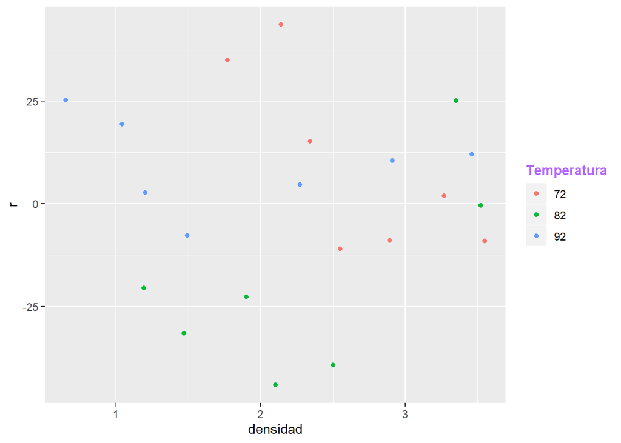

```r
####################################################################
# residuales vs densidad

gg2 = ggplot(resvsest,aes(x = densidad ,y = r,color = as.factor(temperatura)))+geom_point()

gg2 = gg2 +tema + labs(color = "Temperatura")

gg2
```

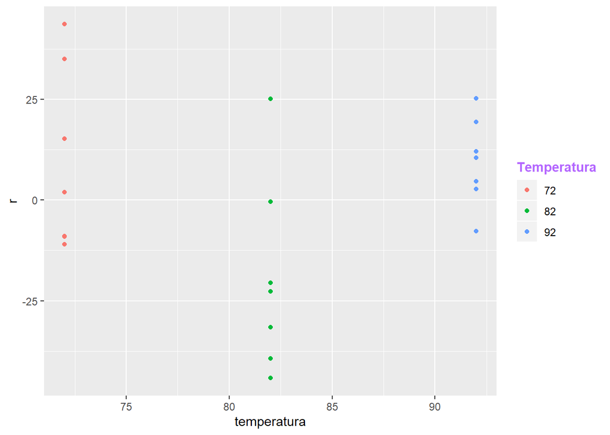

```r
####################################################################
# residuales vs temperatura

gg2 = ggplot(resvsest,aes(x = temperatura ,y = r,color = as.factor(temperatura)))+geom_point()

gg2 = gg2 +tema + labs(color = "Temperatura")

gg2
```

```r
#####################################################################
# obs versus ajustados
gg2 = ggplot(resvsest,aes(x = duracion,y = mu_est,color = as.factor(temperatura)))+geom_point()

gg2 = gg2 +tema + labs(color = "Temperatura")


####################################################################
```

# Analisis de influencia

Numero 1 y 15 parecen tener un leverage alto con respecto a los demas

Buscamos las distancias con valores de hkk que sean mayores de 2 veces hkk barra linea negra y 3 veces hkk barra linea roja

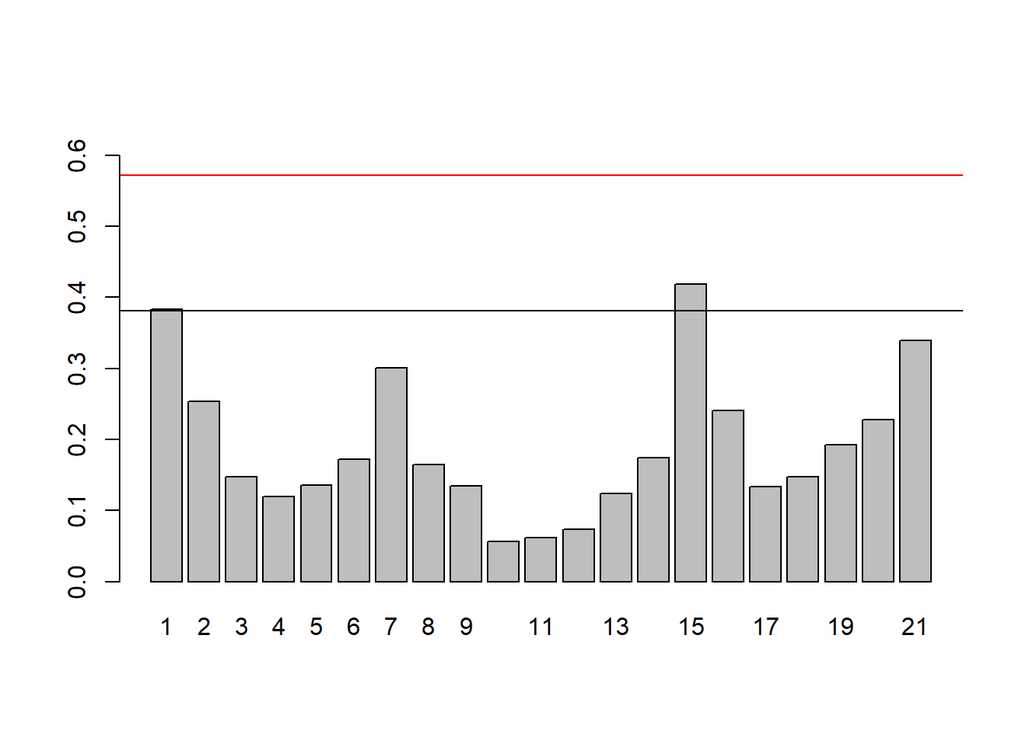

```r
####################################################################
# analisis de infuencia
X = as.matrix(cbind(1,lm1$model[,c(2,3)],lm1$model[,2]*lm1$model[,3]))
hat = X%*%solve(t(X)%*%X)%*%t(X)
hkk = diag(hat)

barplot(hkk,ylim=c(0,0.65))
barp = sum(hkk)/nrow(peliculas) # esto es igual
abline(h = 2*barp)
abline(h = 3*barp,col = 2)
```

# prueba de normalidad

Parece que los residuales si son producto de un modelo con errores normales

```r
########################################################
library(extRemes)
```

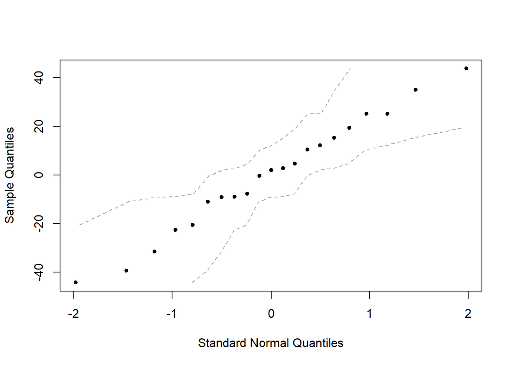

```r
qqnorm(r)
```

```r
#############
# este metodo es via kolmogorov
# Doksum and Sievers, 1976
```

# Prueba de varianza constante

Esto confirma estadísticamente que a un nivel de significancia alpha hay violacion del supuesto de variaza constante

```r
lr = log(r^2)

lmvar = lm(lr~X)

summary(lmvar)
```

```
##
## Call:
## lm(formula = lr ~ X)
##
## Residuals:
##     Min      1Q  Median      3Q     Max
## -5.1234 -0.7268  0.1686  1.1015  2.9596
##
## Coefficients: (1 not defined because of singularities)
##                                   Estimate Std. Error t value Pr(>|t|)
## (Intercept)                       43.04015   15.33748   2.806   0.0121 *
## X1                                      NA         NA      NA       NA
## Xdensidad                        -13.28793    6.00823  -2.212   0.0410 *
## Xtemperatura                      -0.41186    0.17680  -2.329   0.0324 *
## Xlm1$model[, 2] * lm1$model[, 3]   0.14101    0.07032   2.005   0.0611 .
## ---
## Signif. codes:  0 '***' 0.001 '**' 0.01 '*' 0.05 '.' 0.1 ' ' 1
##
## Residual standard error: 2.032 on 17 degrees of freedom
## Multiple R-squared:  0.3653, Adjusted R-squared:  0.2533
## F-statistic: 3.261 on 3 and 17 DF,  p-value: 0.04724
```

# dfbetas

distacias de los modelos con todas las observaciones a el modelo sin la observacion k esima

```r
#######################################################
#dfbetas

df = solve(t(X)%*%X)%*%t(X)*r/(1-hkk)

df
```

```
##                                          1             2           3
## 1                               43.1800858 -33.837803912 -16.1376102
## densidad                         3.5528804  53.141515470 -19.7112316
## temperatura                     -0.3418471   1.073970567  -0.2947302
## lm1$model[, 2] * lm1$model[, 3]  0.1966093   0.005168025   0.1312387
##                                             4           5           6
## 1                               -2.402590e+01  7.60453422 81.63610013
## densidad                         1.054958e-01  2.70631734  8.55392093
## temperatura                     -1.524319e-01 -0.05433217 -0.06024304
## lm1$model[, 2] * lm1$model[, 3] -5.768164e-04  0.08124425 -0.06673245
##                                           7           8           9
## 1                               -43.4931610  0.34742386 13.81198610
## densidad                        -19.3659059  6.36509180 -5.52342641
## temperatura                      -2.0339657 -0.29764945 -0.12878946
## lm1$model[, 2] * lm1$model[, 3]   0.6089377  0.07056633 -0.01808729
##                                           10            11          12
## 1                                5.715242796  21.936891182 -11.5839963
## densidad                        -0.936924667 -12.575235759   5.1008740
## temperatura                      0.042442892   0.137651256  -0.2052583
## lm1$model[, 2] * lm1$model[, 3]  0.007803249   0.009477192   0.2360068
##                                         13          14           15
## 1                               80.1942381 -90.6789213  25.37210028
## densidad                         0.2619762  16.6784899 -12.14471779
## temperatura                     -0.4837198   0.7166877  -0.08638739
## lm1$model[, 2] * lm1$model[, 3] -0.2522498  -0.1764571  -0.10610619
##                                          16          17            18
## 1                                 1.7689302 -0.79502669 -69.653888378
## densidad                        -13.3920780  1.36830446  18.111281844
## temperatura                      -0.2639431 -0.04786047  -0.007727901
## lm1$model[, 2] * lm1$model[, 3]  -0.1058204  0.03305624  -0.133110306
##                                          19          20         21
## 1                                70.5559234 47.31144955 21.7449067
## densidad                        -25.6730828 13.40868836  3.0792443
## temperatura                      -0.5329823  0.33682593  0.7765164
## lm1$model[, 2] * lm1$model[, 3]   0.2514930 -0.04442221 -0.4398464
```

# Distacia de cook

la distancia de cook nos dice que tanto cambia el modelo quitando la i-esima observacion

se onservan los puntos 2 y 7

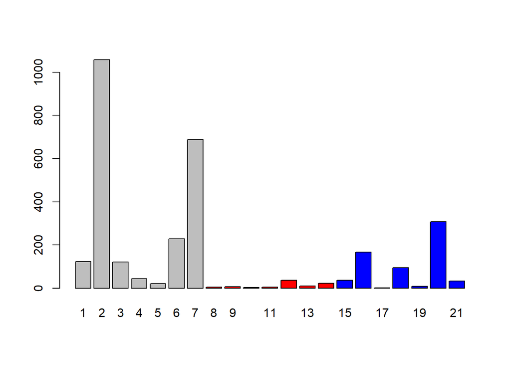

```r
#######################################################
# distacia de cook
sigmag = sum((lm1$residuals)^2)/(dim(X)[1]-dim(X)[2])
cook = diag(t(df)%*%t(X)%*%X%*%df/sigmag)

barplot(cook,col=temperatura)
```

# Interpretaciones de los coeficientes

```r
lm1$coefficients
```

```
##          (Intercept)             densidad          temperatura
##          3308.589284          -834.776634           -34.081194
## densidad:temperatura
##             8.567294
```

-834.7766 significa que por cada unidad que se aumenta en la densidad esperamos que la duracion disminuya en -834.7766 cuando la temperatura permanece igual

-34.08 significa que por cada unidad que se aumenta en la temperatura esperamos que la duracion disminuya en -34.08 cuando la densidad permanece igual

# Prediccion de una observacion con valores densidad = 2 y temperatura = 82

```r
c(1,2,82,164)%*%solve(t(X)%*%X)%*%t(X)%*%duracion
```

```
##          [,1]
## [1,] 249.4144
```

```r
ndata = data.frame(densidad = c(2),temperatura = c(82))
predict.lm(object = lm1,newdata = ndata)
```

```
##        1
## 249.4144
```